```python
import numpy as np
import scipy.stats as sps
import pandas as pd
from tqdm.notebook import tqdm
import warnings

import matplotlib.pyplot as plt
import seaborn as sns

from sklearn.neighbors import KNeighborsClassifier, KNeighborsRegressor
from sklearn.metrics import f1_score, accuracy_score, mean_squared_error
from sklearn.datasets import make_blobs
from sklearn.model_selection import train_test_split
from sklearn.linear_model import LinearRegression
from sklearn import datasets

from statsmodels.nonparametric.kde import kernel_switch
from statsmodels.nonparametric.kde import KDEUnivariate
from statsmodels.nonparametric.kernel_density import KDEMultivariate
from statsmodels.nonparametric.kernel_regression import KernelReg

warnings.filterwarnings('ignore')
sns.set(style='darkgrid', font_scale=1.7, palette='Set2')
```

# Непараметрические методы регрессии и оценки плотности

## 1. Метод $k$ ближайших соседей.

В этом разделе мы посмотрим на пример применения метода kNN для искуственно сгенерированных данных на задаче классификации.

### 1.1. Генерация данных

Сгенерируем данные из двух двумерных гауссовских распределений с помощью функции `make_blobs`.

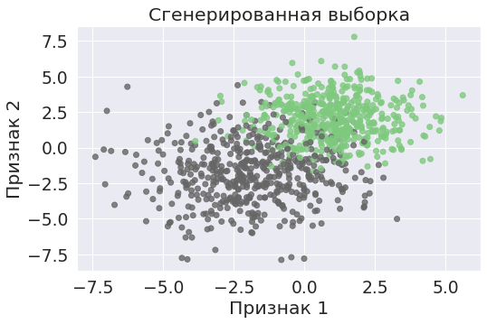

```python
X, y = make_blobs(
    n_samples=(500, 500),  # количество точек в каждом кластере
    centers=[[1, 2], [-2, -2]],  # центры кластеров
    cluster_std=[1.5, 2],  # стандартные отклонения по кластерам
    random_state=42  # зерно случайности
)

plt.figure(figsize=(8, 5))
plt.scatter(X[:, 0], X[:, 1], c=y, alpha=0.8, cmap='Accent')
plt.xlabel('Признак 1'), plt.ylabel('Признак 2')
plt.title('Сгенерированная выборка')
# plt.grid()
plt.show()
```

```python
X.shape, y.shape
```

```
((1000, 2), (1000,))
```

### 1.2. Применение метода

В `sklearn.neighbors` метод kNN представлен классами `KNeighborsClassifier` и `KNeighborsRegressor` для классификации и регрессии соответственно.

Оба метода имеют следующие параметры:

- `n_neighbors` — количество ближайших соседей, используемых для предсказания;
- `weights` — способ вычисления весов объектов из набора $k$ ближайших соседей:
  - `uniform` для одинакового веса для всех точек,
  - `distance` для весов, пропорциональных обратному расстоянию;
- `metric` — метрика, по которой считаются ближайшие соседи;
- `p` — порядок расстояния Минковского между точками: $$\rho(x, y) = \left( \sum_{i=1}^d |x_i - y_i|^p \right)^{1/p};$$
- `algorithm` — алгоритм поиска соседей:
  - `ball_tree` для поиска с помощью BallTree;
  - `kd_tree` для поиска с помощью KDTree;
  - `brute` для поиска с помощью полного перебора;
  - `auto` для выбора наиболее подходящего на основе обучающей выборки.

Разделим на обучающую и тестовую выборки

```python
X_train, X_test, y_train, y_test = train_test_split(X, y, test_size=0.15)

X_train.shape, X_test.shape, y_train.shape, y_test.shape
```

```
((850, 2), (150, 2), (850,), (150,))
```

Обучим метод трех ближайших соседей

```python
model = KNeighborsClassifier(n_neighbors=3, algorithm='brute')
model.fit(X_train, y_train)
```

```
KNeighborsClassifier(algorithm='brute', n_neighbors=3)
```

Качество на тесте

```python
print(f'accuracy: {accuracy_score(y_test, model.predict(X_test)) :.3}')
print(f'f1 score: {f1_score(y_test, model.predict(X_test)) :.3}')
```

```
accuracy: 0.947
f1 score: 0.942
```

### 1.3. Визуализация

Визуализируем предсказания kNN для различных $k$. Для этого вычислим предсказания по сетке и нарисуем полученные классы.

```python
def generate_grid(train_sample, border=1.0, step=0.05):
    '''
    Генерация сетки для вычисления предсказаний.

    :param train_sample: (np.ndarray)
        Точки выборки, по которым строилась модель
    :param border: (float)
        Отступ от максимальных и минимальных значений выборки по обеим координатам
    :param step: (float)
        Шаг сетки
    '''

    return np.meshgrid(
        np.arange(min(train_sample[:, 0]) - border,
                  max(train_sample[:, 0]) + border,
                  step),
        np.arange(min(train_sample[:, 1]) - border,
                  max(train_sample[:, 1]) + border,
                  step)
    )
```

```python
def create_picture(X_train, y_train, model, border=1.0,
                   step=0.05, figsize=(18, 6),
                   cmap='winter', alpha=1):
    '''
    Визуализация предсказаний классов на плоскости и точек обучающей выборки.

    :param X_train:
        Точки обучающей выборки
    :param y_train:
        Классы точек обучающей выборки
    :param model:
        Модель-классификатор, для которой визуализируются предсказания
    '''

    # == Создание сетки ==
    grid = generate_grid(X_train, border, step)
    # Выворачивание сетки для приведения к форме выборки
    grid_ravel = np.c_[grid[0].ravel(), grid[1].ravel()]

    # == Предсказание значений для сетки ==
    # Берем вероятности для первого класса
    grid_predicted_ravel = model.predict_proba(grid_ravel)[:, 1]
    # Подгоняем размер
    grid_predicted = grid_predicted_ravel.reshape(grid[0].shape)


    # == Построение фигуры ==
    plt.figure(figsize=figsize)

    plt.subplot(1, 2, 1)
    plt.pcolormesh(grid[0], grid[1], grid_predicted > 0.5, cmap=cmap)
    plt.scatter(X_train[:, 0], X_train[:, 1], c=y_train,
                alpha=alpha, cmap=cmap, edgecolor='black')
    plt.xlim((min(grid_ravel[:, 0]), max(grid_ravel[:, 0])))
    plt.ylim((min(grid_ravel[:, 1]), max(grid_ravel[:, 1])))
    plt.title(u'Классификация при {}-NN'.format(model.get_params()['n_neighbors']))
    plt.xlabel('Признак 1')
    plt.ylabel('Признак 2')

    plt.subplot(1, 2, 2)
    plt.pcolormesh(grid[0], grid[1], grid_predicted, cmap=cmap)
    plt.scatter(X_train[:, 0], X_train[:, 1], c=y_train,
                alpha=alpha, cmap=cmap, edgecolor='black')
    plt.xlim((min(grid_ravel[:, 0]), max(grid_ravel[:, 0])))
    plt.ylim((min(grid_ravel[:, 1]), max(grid_ravel[:, 1])))
    plt.title(u'Оценка вероятностей в {}-NN'.format(model.get_params()['n_neighbors']))
    plt.xlabel('Признак 1')
    plt.ylabel('Признак 2')

    plt.tight_layout()
    plt.show()
```

Сначала действуем по метрике $L_2$.

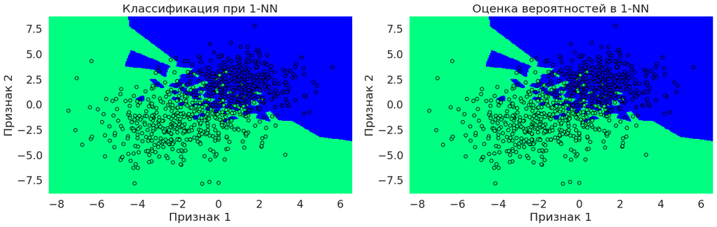

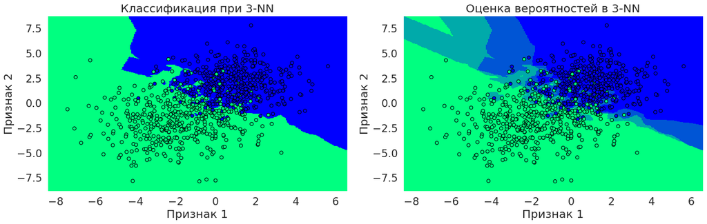

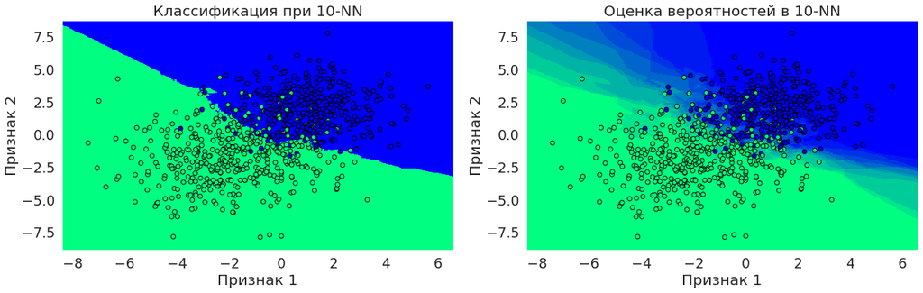

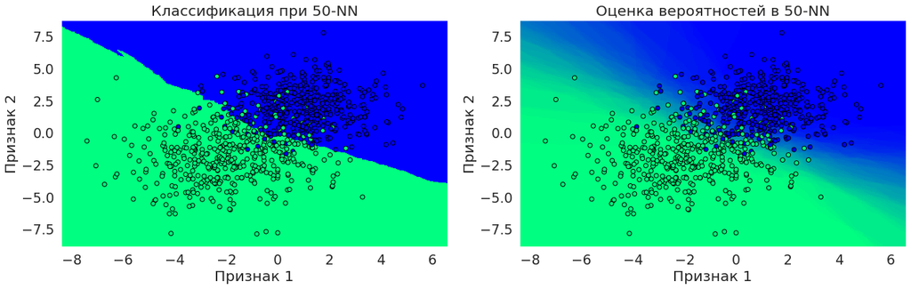

```python
for n_neighbors in [1, 3, 10, 50]:
    create_picture(
        X_train,
        y_train,
        KNeighborsClassifier(n_neighbors=n_neighbors).fit(X_train, y_train)
    )
```

Теперь построим аналогичные графики для метрики $L_1$.

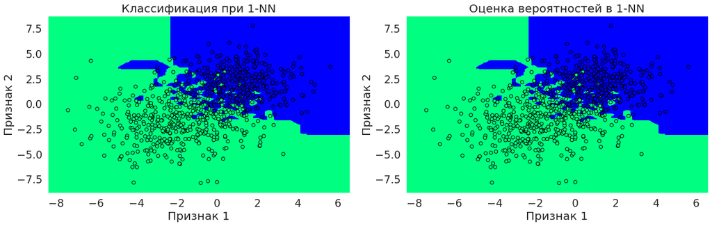

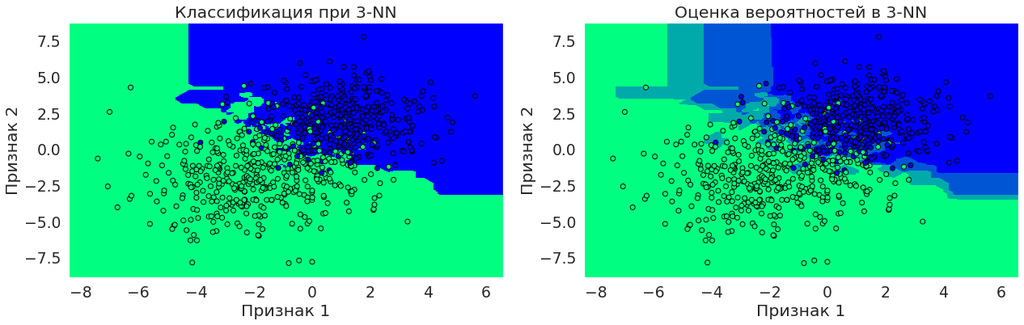

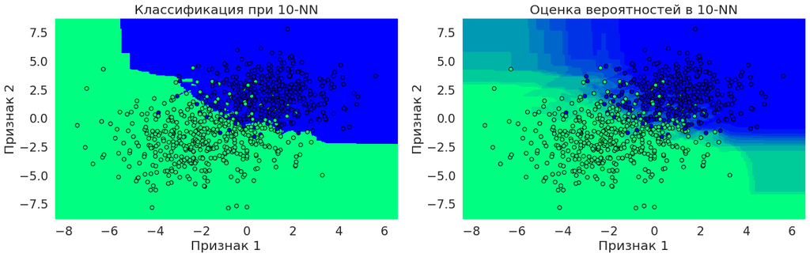

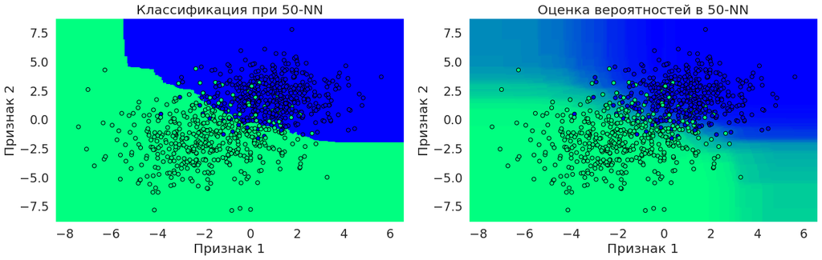

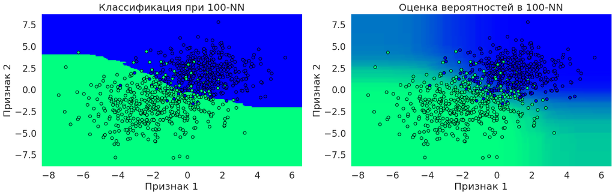

```python
for n_neighbors in [1, 3, 10, 50, 100]:
    create_picture(
        X_train,
        y_train,
        KNeighborsClassifier(n_neighbors=n_neighbors, p=1).fit(X_train, y_train)
    )
```

**Вывод:**

При увеличении числа соседей разделяющая кривая получается более гладкой. При маленьком же числе рассматриваемых соседей модель чувствительна к наложению классов, из-за чего в предсказаниях разделяющая поверхность очень неровная. Также при большом числе классов переход между классами на графике вероятностей намного более плавный.

## 2. Ядерные оценки плотности

### 2.1. Библиотека Seaborn

Отрисовка данных:

> `seaborn.kdeplot(data=None, *, x=None, y=None, hue=None, weights=None, cumulative=False, bw_method='scott', **kwargs)`
- `data` — pandas.DataFrame или np.array с данными;
- `x, y` — название колонок, определяющих оси, если переданы обе, то строит оценку многомерной плотности;
- `hue` — параметр для разбиения выборки;
- `weights` — если переданы, то определяют веса в kde;
- `cumulative` — если True строит cdf вместо плотности;
- `bw_method` — метод для оценки ширины ядра `scott`, `silverman` или число, который потом передается в `scipy.stats.gaussian_kde`;

*Примечание: данный метод использует только гауссовское ядро.*

Посмотрим на примеры.

Одномерные плотности

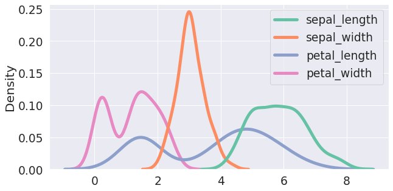

```python
iris = sns.load_dataset("iris")

plt.figure(figsize=(10, 5))
sns.kdeplot(data=iris, lw=5)
plt.show()
```

Многомерная

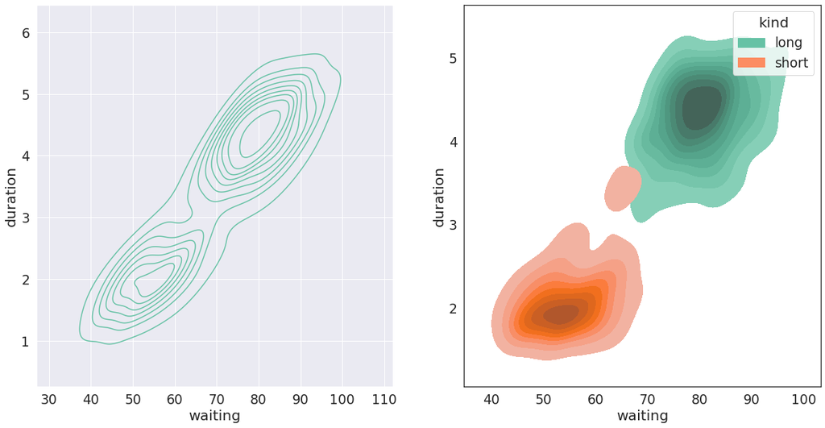

```python
geyser = sns.load_dataset("geyser")

plt.figure(figsize=(20, 10))

plt.subplot(121)
sns.kdeplot(data=geyser, x="waiting", y="duration")

sns.set_style('white')
plt.subplot(122)
sns.kdeplot(data=geyser, x="waiting", y="duration", hue="kind", fill=True)

plt.show()
```

Также можно использовать функцию `sns.displot` с параметром `kind = 'kde'` или `kde = True`, но поменять размер графика увы не получится.

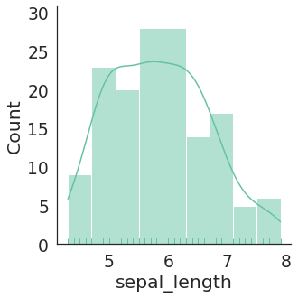

```python
sns.displot(data=iris, x='sepal_length', rug=True, kde=True);
```

### 2.2. Библиотека Statmodels

[Полная документация с примерами](https://www.statsmodels.org/stable/examples/notebooks/generated/kernel_density.html)

#### Ядра

Для начала рассмотрим ядра. В библиотеке `statsmodels` реализованы следующие:

```python
list(kernel_switch.keys())
```

```
['gau', 'epa', 'uni', 'tri', 'biw', 'triw', 'cos', 'cos2']
```

Нарисуем эти ядра.

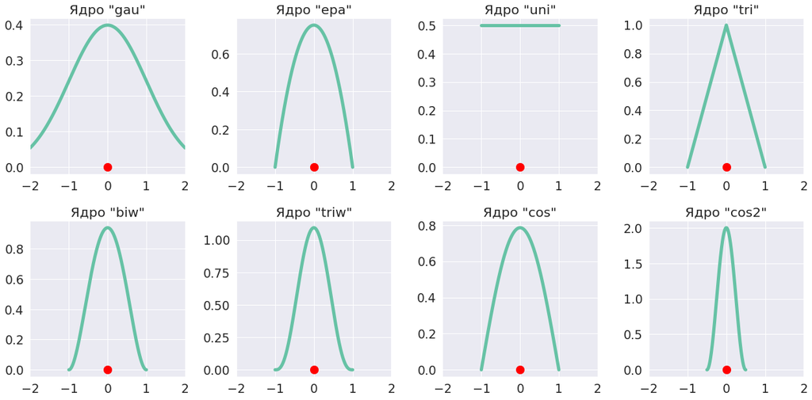

```python
sns.set_style('darkgrid')

fig = plt.figure(figsize=(18, 9))

for i, (ker_name, ker_class) in enumerate(kernel_switch.items()):

    kernel = ker_class()  # ядро
    domain = kernel.domain or [-2, 2]  # носитель
    x_vals = np.linspace(*domain, 2**10)
    y_vals = kernel(x_vals)

    ax = fig.add_subplot(2, 4, i + 1)
    ax.set_title('Ядро "{}"'.format(ker_name))
    ax.plot(x_vals, y_vals, lw=5, label='{}'.format(ker_name))
    ax.scatter([0], [0], color='red', s=150)
    plt.grid(True, zorder=-5)
    ax.set_xlim((-2, 2))

plt.tight_layout()
```

Посморим, как будет выглядеть ядерная оценка плотности в зависимости от типа ядра, взяв в качестве реализации выборки набор точек [-1, 0, 1].

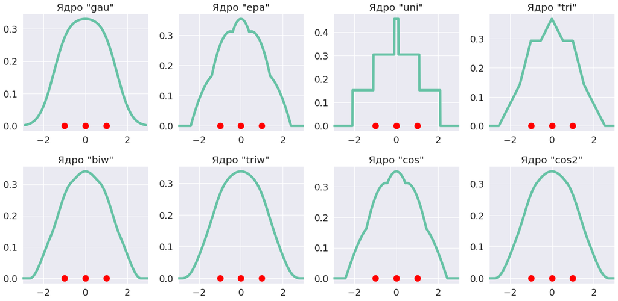

```python
data = np.linspace(-1, 1, 3)  # выборка
kde = KDEUnivariate(data)  # объект, выполняющий построение оценки

fig = plt.figure(figsize=(18, 9))

for i, kernel in enumerate(kernel_switch.keys()):

    ax = fig.add_subplot(2, 4, i + 1)
    ax.set_title('Ядро "{}"'.format(kernel))

    # построение ядерной оценки плотности с заданным ядром
    kde.fit(kernel=kernel, fft=False, gridsize=2**10)
    # отрисовка полученной оценки
    ax.plot(kde.support, kde.density, lw=5, zorder=10)
    # отрисовка выборки
    ax.scatter(data, np.zeros_like(data), color='red', s=150)
    plt.grid(True, zorder=-5)
    ax.set_xlim([-3, 3])

plt.tight_layout()
```

**1. Гауссовское.**

- *Преимущество* — бесконечно гладкое, что полезно в случаях, когда требуется получить гладкую плотность. Например, в задачах оптимизации.
- *Недостаток* — вычисление экспонента довольно затратно по времени.

**2. Епаничнекова.**

- *Преимущество* — обладает оптимальностью по точности приближения по MSE, вычисления не сильно трудоемки, поскольку плотность состоит из параболы.
- *Недостаток* — не является гладкой, но при этом непрерывна.

**3. Равномерное.**

- *Преимущество* — легко вычислять, нет трудоемких операций.
- *Недостаток* — даже не является непрерывным, что сказывается даже на визуальном восприятии плотности.

#### Оценка плотности

Класс для оценки **одномерной плотности** с любым ядром:

> `statsmodels.nonparametric.kde.KDEUnivariate`

*Общий пайплайн*:

```
kde = KDEUnivariate(data)
kde.fit(kernel, bw, fft, weights, gridsize)
kde.{density, cdf, bw}
```

*Аргументы*:

- `kernel` — ядро, по умолчанию гауссовское;
- `bw` — ширина ядра

*Подробнее*:

- https://www.statsmodels.org/stable/generated/statsmodels.nonparametric.kde.KDEUnivariate.fit.html
- https://www.statsmodels.org/stable/generated/statsmodels.nonparametric.kde.KDEUnivariate.html

Класс для оценки **многомерной плотности**, использует гауссовское ядро.

> `statsmodels.nonparametric.kernel_density.KDEMultivariate`

*Общий пайплайн*:

```
kde = KDEMultivariate(data, var_type)
kde.{pdf, cdf}(points)
```

*Аргументы*:

- `data` — данные для обучения;
- `var_type` — типы признаков:
  - `c` — вещественный,
  - `o` — дискретный,
  - `u` — категориальный;
- `points` — точки в которых, берем значения.

*Подробнее*:

- https://www.statsmodels.org/stable/generated/statsmodels.nonparametric.kernel_density.KDEMultivariate.html

Сгенерируем простую выборку и построим по ней KDE

```python
obs_dist = sps.norm.rvs(size=1000)
kde = KDEUnivariate(obs_dist)
kde.fit();
```

Нарисуем график

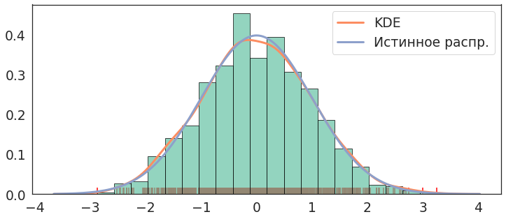

```python
sns.set_style('white')

fig = plt.figure(figsize=(12, 5))

# Гистограмма
plt.hist(
    obs_dist,
    bins=20,
    density=True,
    edgecolor="k",
    alpha=0.7
)

# Ядерная оценка плотности
plt.plot(kde.support, kde.density, lw=3, label="KDE")

# Истинное распределение
true_values = sps.norm.pdf(x=kde.support)
plt.plot(kde.support, true_values, lw=3, label="Истинное распр.")

# Выборка
plt.scatter(
    obs_dist,
    np.zeros(len(obs_dist)),
    marker="|",
    color="red",
    s=300
)

plt.legend(loc="best");
```

Посмотрим на оценку многомерного распределения

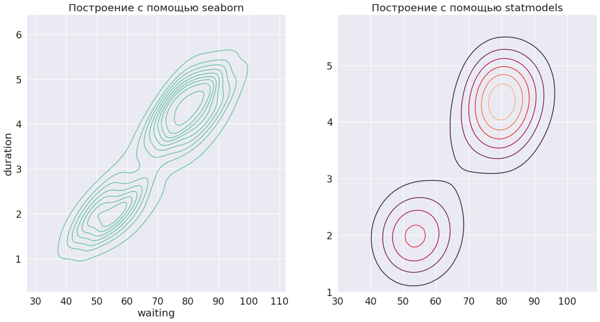

```python
geyser = sns.load_dataset("geyser")

sns.set_style('darkgrid')
plt.figure(figsize=(20, 10))

plt.subplot(121)
plt.title('Построение с помощью seaborn')
sns.kdeplot(data=geyser, x="waiting", y="duration")

plt.subplot(122)
plt.title('Построение с помощью statmodels')
kde = KDEMultivariate(geyser[['waiting', 'duration']], var_type='cc')
x, y = np.mgrid[30:110, 1:6:.1]
pos = np.dstack((x.reshape(-1, 1), y.reshape(-1, 1)))
plt.contour(x, y, kde.pdf(pos).reshape(x.shape))

plt.show()
```

## 3. Ядерная регрессия

[Документация](https://www.statsmodels.org/dev/generated/statsmodels.nonparametric.kernel_regression.KernelReg.html)

> `reg = KernelReg(y_train, X_train, var_type, reg_type='ll', bw='cv_ls', ckertype='gaussian', okertype='wangryzin', ukertype='aitchisonaitken', defaults=None)`

*Методы класса*:

- `reg.fit(X=X_train)` — возвращает предсказания для входа;
- `reg.aic_hurvich(bw)` — возвращает подправленый AIC критерий для ширины;
- `reg.r_squared()` — возвращает коэффициент детерминации для модели.

*Аргументы*:

- `X_train`, `Y_train` — выборка;
- `var_type` — типы признаков:
  - `c` — вещественный,
  - `o` — дискретный,
  - `u` — категориальный;
- `bw` — ширина ядра;
- `{c,o,u}kertype` — тип ядра для соотвествующего типа переменных.

Возьмем датасет о зависимости заработной платы (логарифм) от возраста по данным переписи населения в Канаде 1971 года. Датасет содержит информацию о 205 мужчинах, имеющих одинаковое образование (grade 13).

```python
data = pd.read_csv('cps71.csv', index_col = 0)
data.head()
```

|  | logwage | age |
| --- | --- | --- |
| 1 | 11.1563 | 21 |
| 2 | 12.8131 | 22 |
| 3 | 13.0960 | 22 |
| 4 | 11.6952 | 22 |
| 5 | 11.5327 | 22 |

Выделим признак и таргет, обучим модель

```python
X = data['age']
y = data['logwage']

reg = KernelReg(y, X, var_type='o')
y_pred = reg.fit()
```

Для сравнения обучим линейную регрессию

```python
lin_reg = LinearRegression().fit(X.values.reshape(-1, 1), y)
y_lin_pred = lin_reg.predict(X.values.reshape(-1, 1))
```

Сравним

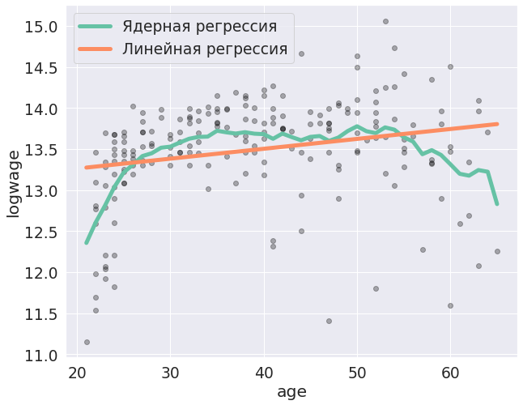

```python
plt.figure(figsize=(10, 8))
plt.scatter(X, y, color='black', alpha=0.3)
plt.plot(X, y_pred[0], lw=5, label='Ядерная регрессия')
plt.plot(X, y_lin_pred, lw=5, label='Линейная регрессия')
plt.xlabel('age')
plt.ylabel('logwage')
plt.legend()
plt.show()
```

Посмотрим также предсказания в зависимости от `var_type`

```python
c_reg = KernelReg(y, X, var_type='c')
y_c_pred = c_reg.fit()

u_reg = KernelReg(y, X, var_type='u')
y_u_pred = u_reg.fit()
```

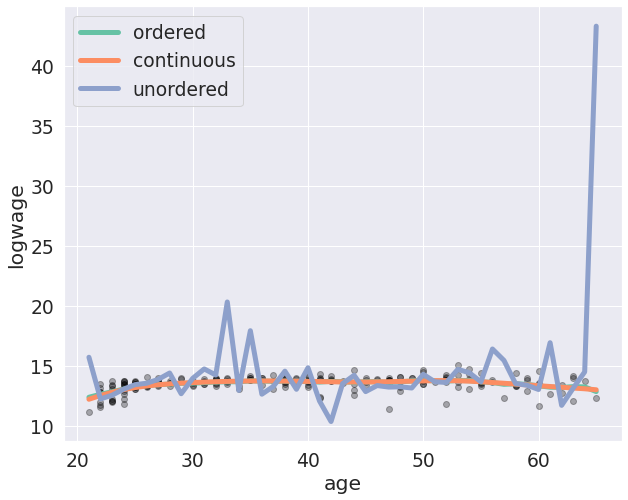

```python
plt.figure(figsize=(10, 8))
plt.scatter(X, y, color='black', alpha=0.3)
plt.plot(X, y_pred[0], lw=5, label='ordered')
plt.plot(X, y_c_pred[0], lw=5, label='continuous')
plt.plot(X, y_u_pred[0], lw=5, label='unordered')
plt.xlabel('age')
plt.ylabel('logwage')
plt.legend()
plt.show()
```

Уберем с графика тип unordered

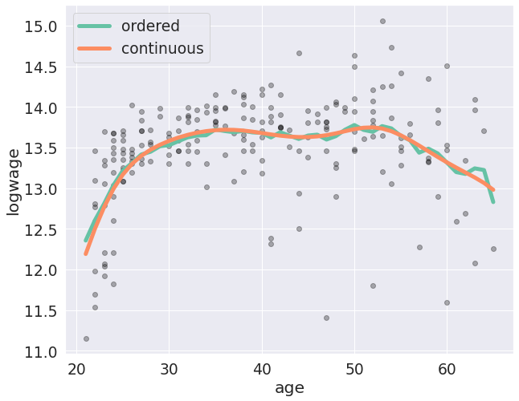

```python
plt.figure(figsize=(10, 8))
plt.scatter(X, y, color='black', alpha=0.3)
plt.plot(X, y_pred[0], lw=5, label='ordered')
plt.plot(X, y_c_pred[0], lw=5, label='continuous')
plt.xlabel('age')
plt.ylabel('logwage')
plt.legend()
plt.show()
```

Обучим также kNN-регрессию для 5 и 15 соседей

```python
knn_reg = KNeighborsRegressor(n_neighbors=5).fit(X.values.reshape(-1, 1), y)
y_knn_pred_5 = knn_reg.predict(X.values.reshape(-1, 1))

knn_reg = KNeighborsRegressor(n_neighbors=15).fit(X.values.reshape(-1, 1), y)
y_knn_pred_15 = knn_reg.predict(X.values.reshape(-1, 1))
```

Сравним предсказания

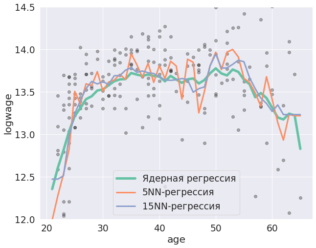

```python
plt.figure(figsize=(10, 8))
plt.scatter(X, y, color='black', alpha=0.3)
plt.plot(X, y_pred[0], lw=5, label='Ядерная регрессия')
plt.plot(X, y_knn_pred_5, lw=3, label='5NN-регрессия')
plt.plot(X, y_knn_pred_15, lw=3, label='15NN-регрессия')
plt.xlabel('age')
plt.ylabel('logwage')
plt.ylim((12, 14.5))
plt.legend()
plt.show()
```

Сравним метрики моделей

```python
print(f"Ядерная регрессия: {mean_squared_error(y, y_pred[0]):.4f}")
print(f"Линейная регрессия: {mean_squared_error(y, y_lin_pred):.4f}")
print(f"5NN регрессия: {mean_squared_error(y, y_knn_pred_5):.4f}")
print(f"15NN регрессия: {mean_squared_error(y, y_knn_pred_15):.4f}")
print(f"Ядерная регрессия (неверный тип c): {mean_squared_error(y, y_c_pred[0]):.4f}")
print(f"Ядерная регрессия (неверный тип u): {mean_squared_error(y, y_u_pred[0]):.4f}")
```

```
Ядерная регрессия: 0.2678
Линейная регрессия: 0.3813
5NN регрессия: 0.2687
15NN регрессия: 0.2733
Ядерная регрессия (неверный тип c): 0.2751
Ядерная регрессия (неверный тип u): 7.4100
```